# 統計遺伝学月曜最終課題

Daisuke Takada

2018/7/30

# Ten quick tips for machine learning in computational biology

データがあった方がイメージがしやすかったため、以下の本のデータを転用。 https://www.kanehara-shuppan.co.jp/books/detail.html?isbn=9784307004848

# Tip1 Check and arrange your input dataset property

そもそも機械学習をすべきか否かだが、  
今回は臨床上明らかな交絡因子と考えられる説明変数で交絡調整を行うためただのロジスティック回帰分析(上記参考書では傾向スコアの方法に特化している)でも良い  
しかし今回は勉強のため、lasso回帰を行い、制約をつける事でどの変数から落ちていくのかを確認する事も目的とする。

## 下記の(仮想上の)データセットを用いる

| id | sex | Age | HT | DM | Stroke | MI | TreatmentX | sequela | LOS | ADL_disc |
| --- | --- | --- | --- | --- | --- | --- | --- | --- | --- | --- |
| 1 | 男 | 74 | 0 | 0 | 0 | 0 | 0 | 0 | 23 | 45 |
| 2 | 女 | 73 | 1 | 0 | 0 | 1 | 0 | 1 | 24 | 40 |
| 3 | 男 | 75 | 0 | 0 | 0 | 0 | 0 | 0 | 24 | 40 |
| 4 | 男 | 76 | 0 | 0 | 0 | 0 | 0 | 0 | 24 | 40 |
| 5 | 女 | 80 | 0 | 0 | 0 | 0 | 0 | 0 | 26 | 40 |
| 6 | 男 | 76 | 0 | 0 | 0 | 0 | 0 | 0 | 23 | 40 |

`str(usagi)`

```
## 'data.frame':    15000 obs. of  11 variables:
##  $ id        : int  1 2 3 4 5 6 7 8 9 10 ...
##  $ sex       : Factor w/ 2 levels "女","男": 2 1 2 2 1 2 1 1 1 1 ...
##  $ Age       : int  74 73 75 76 80 76 74 78 72 75 ...
##  $ HT        : int  0 1 0 0 0 0 0 0 0 0 ...
##  $ DM        : int  0 0 0 0 0 0 0 0 0 0 ...
##  $ Stroke    : int  0 0 0 0 0 0 0 0 0 0 ...
##  $ MI        : int  0 1 0 0 0 0 0 0 0 0 ...
##  $ TreatmentX: int  0 0 0 0 0 0 0 0 0 1 ...
##  $ sequela   : int  0 1 0 0 0 0 0 0 0 0 ...
##  $ LOS       : int  23 24 24 24 26 23 21 25 21 21 ...
##  $ ADL_disc  : int  45 40 40 40 40 40 40 40 45 45 ...
```

- 各変数の説明
  - Age：入院時年齢
  - HT：高血圧の有無
  - DM：糖尿病の有無
  - Stroke：脳卒中の既往の有無
  - MI：心筋梗塞の既往の有無
  - TreatmentX：治療薬Xの使用の有無
  - sequela：退院時後遺症の有無
  - ADL_disc：退院時ADLスコア；[0-100]の連続変数

利便性のために論理型にしておく。

```r
#dput(names(usagi))
vars <- c("HT","DM","Stroke","MI","TreatmentX","sequela")
usagi[vars] <- lapply(usagi[vars],as.logical)
usagi$sex_cat <- ifelse(usagi$sex=="男",TRUE,FALSE)
str(usagi) #構造
```

[output not shown]

現在の目的は治療薬Xを使用した場合に退院時後遺症に及ぼす影響を確認する事とする。  
交絡因子として、年齢・高血圧の有無・糖尿病の有無・脳卒中既往の有無・心筋梗塞の記憶の有無を考慮する。

## まずはデータの読み込みと確認(集計の基礎)

- ヒストグラム

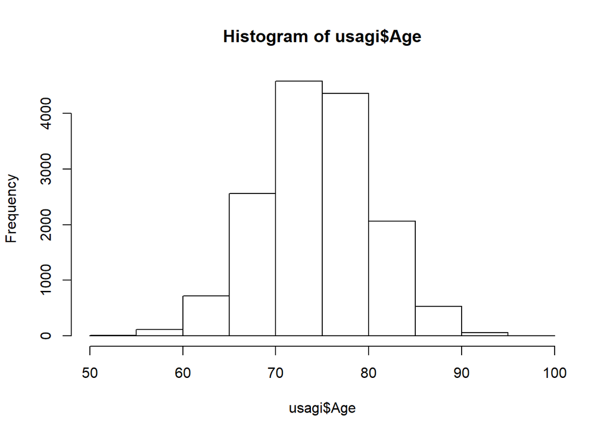

```r
hist(usagi$Age)
```

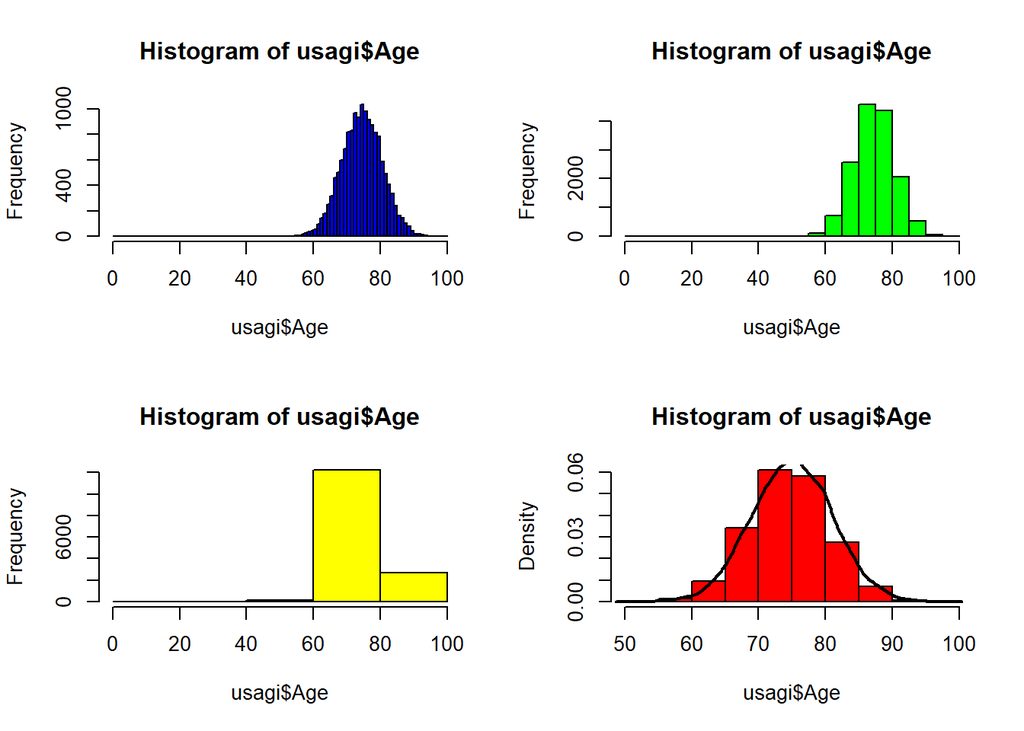

```r
par(mfrow=c(2,2))
hist(usagi$Age, breaks=seq(0,100,1), col="blue")
hist(usagi$Age, breaks=seq(0,100,5), col="green")
hist(usagi$Age, breaks=seq(0,100,20), col="yellow")
hist(usagi$Age,freq=FALSE, col="red")
lines(density(usagi$Age), col = "black", lwd = 2)
```

授業の真似事をしたかったが、症例数が多すぎてどれも正規分布にみえるため、うまい事説明できない。

## 授業でやった真似事をしてみる。

適当に指数分布からデータセットを作り、症例数を増やした場合と少ない場合で確立密度分布のイメージがどれだけ変わるかを確認する。

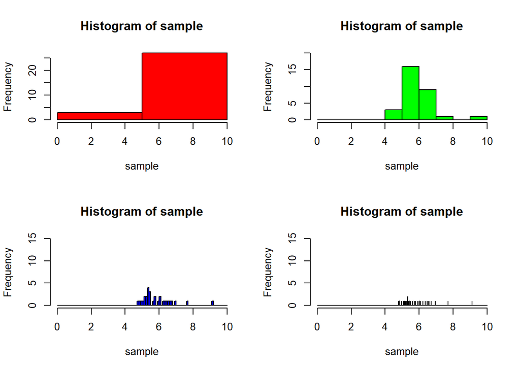

```r
n <- 30
set.seed(123)
sample <- rexp(n, rate = 1)+rnorm(n)*0.2+5
par(mfrow=c(2,2))
hist(sample, breaks=seq(0,10,5), col="red")
hist(sample, breaks=seq(0,10,1),ylim=c(0,20), col="green")
hist(sample, breaks=seq(0,10,0.1),ylim=c(0,15), col="blue")
hist(sample, breaks=seq(0,10,0.01),ylim=c(0,15), col="yellow")
```

どのヒストグラムが最もセンスがあるか。確率密度分布がイメージしやすいものという結論に至った。

## 確率密度分布

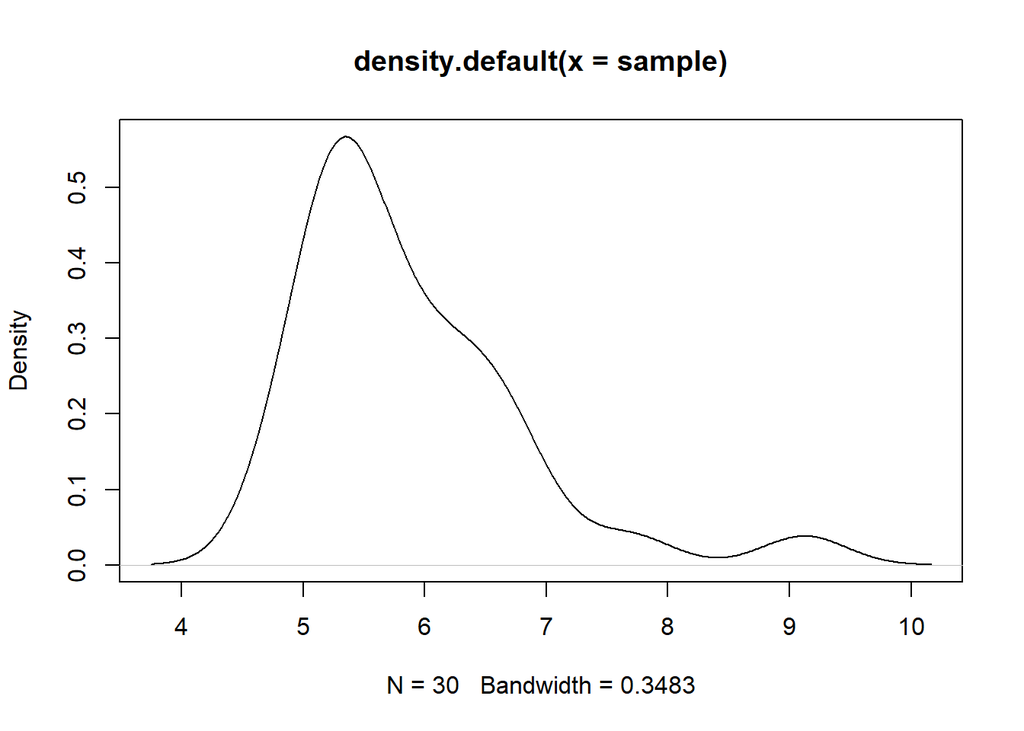

```r
plot(density(sample))
```

しかし確率密度分布も色々な書き方がある。

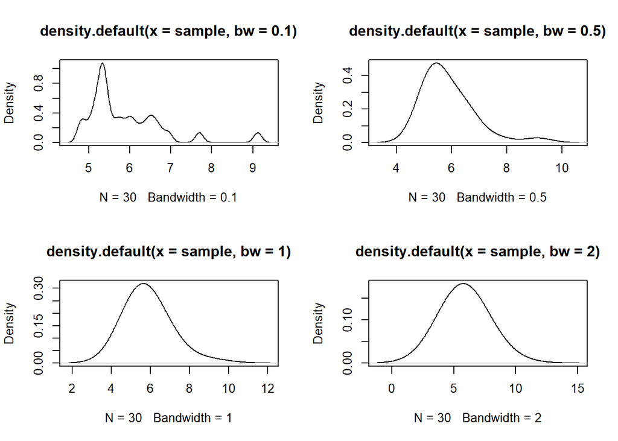

```r
par(mfrow=c(2,2))
plot(density(sample,bw=0.1))
plot(density(sample,bw=0.5))
plot(density(sample,bw=1))
plot(density(sample,bw=2))
```

本来は指数分布(+定数+ランダムエラー)から取り出していた  
真の母集団の分布に近いものを図示するためにN(サンプル数)を増やしてみる。

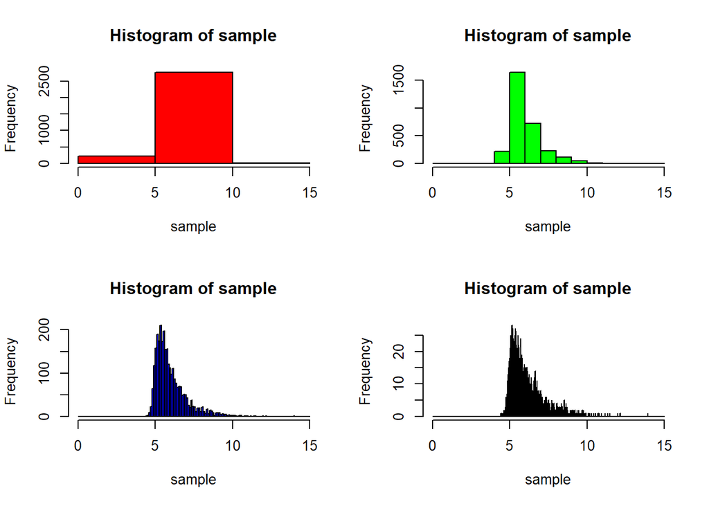

```r
n <- 3000
set.seed(123)
sample <- rexp(n, rate = 1)+rnorm(n)*0.2+5
par(mfrow=c(2,2))
hist(sample, breaks=seq(0,15,5), col="red")
hist(sample, breaks=seq(0,15,1), col="green")
hist(sample, breaks=seq(0,15,0.1), col="blue")
hist(sample, breaks=seq(0,15,0.01), col="yellow")
```

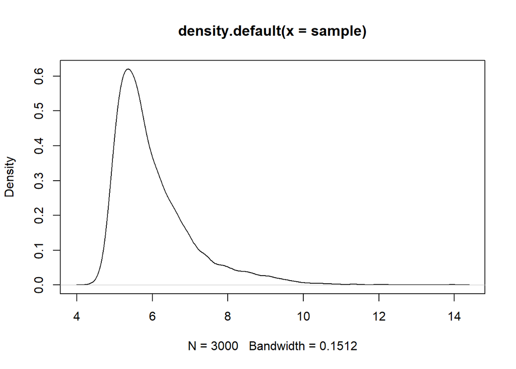

```r
plot(density(sample))
```

真実に近づく

## データチェック(集計の基礎)

LASSO回帰をする際に、離散変数をどのように扱ってscale()をどのように統一するべきかが解らなかったので、いくらかダミー変数も作って二値変数に統一できるようにおく。

```r
usagi$age_cat <- cut(usagi$Age, breaks=c(-Inf,65,75,85,Inf),
                                           labels = c("0","1","2","3"),
                                           ordered_result = FALSE)
usagi$age_cat0 <- ifelse(usagi$age_cat=="0",1,0)
usagi$age_cat1 <- ifelse(usagi$age_cat=="1",1,0)
usagi$age_cat2 <- ifelse(usagi$age_cat=="2",1,0)
usagi$age_cat3 <- ifelse(usagi$age_cat=="3",1,0)
addmargins(xtabs(~age_cat0,data=usagi))
```

```
## age_cat0
##     0     1   Sum
## 14154   846 15000
```

治療と各交絡因子のテーブルをひたすら作る。

```r
addmargins(xtabs(~TreatmentX + sex_cat,data=usagi))
```

```
##           sex_cat
## TreatmentX FALSE  TRUE   Sum
##      FALSE  3828  5825  9653
##      TRUE   2132  3215  5347
##      Sum    5960  9040 15000
```

```r
addmargins(xtabs(~TreatmentX + DM,data=usagi))
```

```
##           DM
## TreatmentX FALSE  TRUE   Sum
##      FALSE  9166   487  9653
##      TRUE   3793  1554  5347
##      Sum   12959  2041 15000
```

```r
addmargins(xtabs(~TreatmentX + Stroke,data=usagi))
```

```
##           Stroke
## TreatmentX FALSE  TRUE   Sum
##      FALSE  9543   110  9653
##      TRUE   4470   877  5347
##      Sum   14013   987 15000
```

```r
addmargins(xtabs(~TreatmentX + MI,data=usagi))
```

```
##           MI
## TreatmentX FALSE  TRUE   Sum
##      FALSE  9355   298  9653
##      TRUE   4207  1140  5347
##      Sum   13562  1438 15000
```

連続変数は分布図にする。

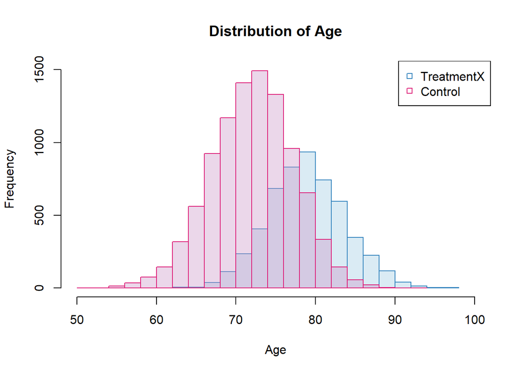

## table1的なものもつくっておく。

```
##                       Stratified by TreatmentX
##                        FALSE         TRUE          p      test
##   n                     9653          5347
##   sex = 男 (%)          5825 (60.3)   3215 (60.1)   0.808
##   Age (mean (sd))      72.59 (5.18)  79.35 (4.82)  <0.001
##   HT = TRUE (%)         1170 (12.1)   2522 (47.2)  <0.001
##   DM = TRUE (%)          487 ( 5.0)   1554 (29.1)  <0.001
##   Stroke = TRUE (%)      110 ( 1.1)    877 (16.4)  <0.001
##   MI = TRUE (%)          298 ( 3.1)   1140 (21.3)  <0.001
##   sequela = TRUE (%)     839 ( 8.7)    403 ( 7.5)   0.015
##   LOS (mean (sd))      21.92 (3.52)  26.41 (5.52)  <0.001
##   ADL_disc (mean (sd)) 43.83 (4.97)  38.37 (6.14)  <0.001
```

# TIP2 データセットを3つにわける。

パラメータいくつか知らないので、教科書のようにトレーニングとtestの2つのみではなく、validation用のデータも作成しておく。

- 15000症例あるので、
  - 50%:training set 7500症例
  - 30%:validation set 4500症例
  - 20%:test set 3000症例  
    もともとがランダムサンプリングと仮定して、とりあえず順番に選ぶ。

```r
train <- usagi[1:7500,]
valid <- usagi[7501:12000,]
tests <- usagi[12001:15000,]
```

# TIP3 biologicalな疑問を簡単なアルゴリズムカテゴリーに変える。

現在行おうとしている事は、教師あり学習の中の 1. 退院時後遺症の有無を予想(分類っぽいが回帰分析で) 2. 退院時ADLの値を予想（時間があれば、回帰も） なので、  
1であれば一般化線形モデル(ロジット関数・二項分布・通常の線形予測子)  
2であれば一般線形モデル  
で最も簡単となる。

# TIP4 どのアルゴリズムを用いるべきか→シンプルなもの！

## ロジスティック回帰分析

$$g(y) = \beta_0x_0 + \beta_1x_1 + \cdots + \beta_nx_n$$
確率分布(確率密度関数)：
$$予想している変数(左辺;応答変数g(y))の予想している分布$$
リンク関数：
$$g(y) \ と　\ y　の関係$$
線形予測子：
$$\beta_0x_0 + \beta_1x_1 + \cdots + \beta_nx_n \ の式の事$$
ロジスティック回帰分析：二項分布を確立密度関数とし、リンク関数をロジットリンク関数とし、線形予測子には各説明変数の一次の項のみを使用した一般化線形モデルを用いた回帰を分析する事。

## まずは単変量(unadjusted)で

```r
result1_0 <- glm(sequela~ TreatmentX, family= binomial(link="logit"),data=train)
summary(result1_0)
```

```
##
## Call:
## glm(formula = sequela ~ TreatmentX, family = binomial(link = "logit"),
##     data = train)
##
## Deviance Residuals:
##     Min       1Q   Median       3Q      Max
## -0.4284  -0.4284  -0.4284  -0.3767   2.3155
##
## Coefficients:
##                Estimate Std. Error z value Pr(>|z|)
## (Intercept)    -2.34253    0.05096 -45.964  < 2e-16 ***
## TreatmentXTRUE -0.26738    0.09182  -2.912  0.00359 **
## ---
## Signif. codes:  0 '***' 0.001 '**' 0.01 '*' 0.05 '.' 0.1 ' ' 1
##
## (Dispersion parameter for binomial family taken to be 1)
##
##     Null deviance: 4210.8  on 7499  degrees of freedom
## Residual deviance: 4202.1  on 7498  degrees of freedom
## AIC: 4206.1
##
## Number of Fisher Scoring iterations: 5
```

```r
result1_0odds <- as.data.frame(cbind(exp(summary(result1_0)$coefficient[,1]),exp(confint(result1_0)),summary(result1_0)$coefficient[,4]))
names(result1_0odds) <- c("Odds ratio","lower 95%CI","upper 95%CI","P value")
result1_0odds
```

|  | Odds ratio | lower 95%CI | upper 95%CI | P value |
| --- | --- | --- | --- | --- |
| (Intercept) | 0.0960838 | 0.0868283 | 0.1060341 | 0.0000000 |
| TreatmentXTRUE | 0.7653858 | 0.6380959 | 0.9147454 | 0.0035935 |

```r
#四捨五入
round(result1_0odds,3)
```

|  | Odds ratio | lower 95%CI | upper 95%CI | P value |
| --- | --- | --- | --- | --- |
| (Intercept) | 0.096 | 0.087 | 0.106 | 0.000 |
| TreatmentXTRUE | 0.765 | 0.638 | 0.915 | 0.004 |

## 次は多変数で

|  | Odds ratio | lower 95%CI | upper 95%CI | P value |
| --- | --- | --- | --- | --- |
| (Intercept) | 0.095 | 0.025 | 0.363 | 0.001 |
| TreatmentXTRUE | 0.562 | 0.449 | 0.702 | 0.000 |
| Age | 0.999 | 0.981 | 1.018 | 0.928 |
| sex男 | 0.996 | 0.840 | 1.182 | 0.962 |
| HTTRUE | 1.320 | 1.025 | 1.691 | 0.029 |
| DMTRUE | 1.231 | 0.888 | 1.692 | 0.206 |
| StrokeTRUE | 1.511 | 1.068 | 2.121 | 0.018 |
| MITRUE | 1.300 | 0.913 | 1.847 | 0.144 |

ロジスティック回帰分析自体はこれで終了

# TIP5 バランスの悪いデータセット問題

パラメータの数と比較してデータ数が多いので今回は問題ないと判断した。 はずれ値の調整なども今回入るのかもしれないが、その点は上記の元データの確認の所である程度見たので良しとしよう。

# TIP6 ハイパーパラメーターの最適化

おそらく中間層をいくつにするかなどの問題がメインだが、今回はスパース正則化を用いているため、解パス図を用いてその代用とする。

## 以下LASSO回帰を開始する。

```r
train <- as.matrix(train)
#x_lasso <- scale(x_lasso)      # 説明変数を標準化するとうまくいかない???
```

```r
summary(data.frame(train))#meanは01ちゃうし割合として矛盾無さそう、他はすべて01
```

```
##        HT              DM             Stroke              MI
##  Min.   :0.000   Min.   :0.0000   Min.   :0.00000   Min.   :0.00000
##  1st Qu.:0.000   1st Qu.:0.0000   1st Qu.:0.00000   1st Qu.:0.00000
##  Median :0.000   Median :0.0000   Median :0.00000   Median :0.00000
##  Mean   :0.248   Mean   :0.1392   Mean   :0.06707   Mean   :0.09733
##  3rd Qu.:0.000   3rd Qu.:0.0000   3rd Qu.:0.00000   3rd Qu.:0.00000
##  Max.   :1.000   Max.   :1.0000   Max.   :1.00000   Max.   :1.00000
##    TreatmentX        sequela          sex_cat          age_cat0
##  Min.   :0.0000   Min.   :0.0000   Min.   :0.0000   Min.   :0.00000
##  1st Qu.:0.0000   1st Qu.:0.0000   1st Qu.:0.0000   1st Qu.:0.00000
##  Median :0.0000   Median :0.0000   Median :1.0000   Median :0.00000
##  Mean   :0.3581   Mean   :0.0808   Mean   :0.6033   Mean   :0.05387
##  3rd Qu.:1.0000   3rd Qu.:0.0000   3rd Qu.:1.0000   3rd Qu.:0.00000
##  Max.   :1.0000   Max.   :1.0000   Max.   :1.0000   Max.   :1.00000
##     age_cat1         age_cat2         age_cat3
##  Min.   :0.0000   Min.   :0.0000   Min.   :0.00000
##  1st Qu.:0.0000   1st Qu.:0.0000   1st Qu.:0.00000
##  Median :0.0000   Median :0.0000   Median :0.00000
##  Mean   :0.4776   Mean   :0.4263   Mean   :0.04227
##  3rd Qu.:1.0000   3rd Qu.:1.0000   3rd Qu.:0.00000
##  Max.   :1.0000   Max.   :1.0000   Max.   :1.00000
```

```r
x_lasso <- train[,-1]
y_lasso <- train[,1]
library(glmnet)
glmnet_fit <- glmnet(x_lasso, y_lasso, family="binomial")
```

解パス図

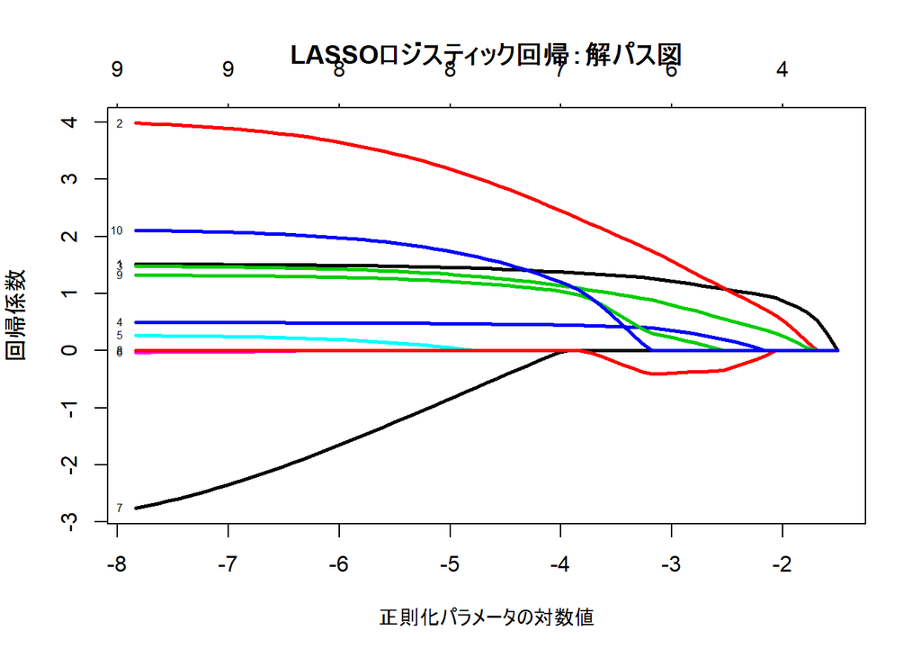

参考：

```r
head(data.frame(train),1)
```

| HT | DM | Stroke | MI | TreatmentX | sequela | sex_cat | age_cat0 | age_cat1 | age_cat2 | age_cat3 |
| --- | --- | --- | --- | --- | --- | --- | --- | --- | --- | --- |
| 0 | 0 | 0 | 0 | 0 | 0 | 1 | 0 | 1 | 0 | 0 |

交差検証プロット：でLambda 正則化パラメーターの効果を確認

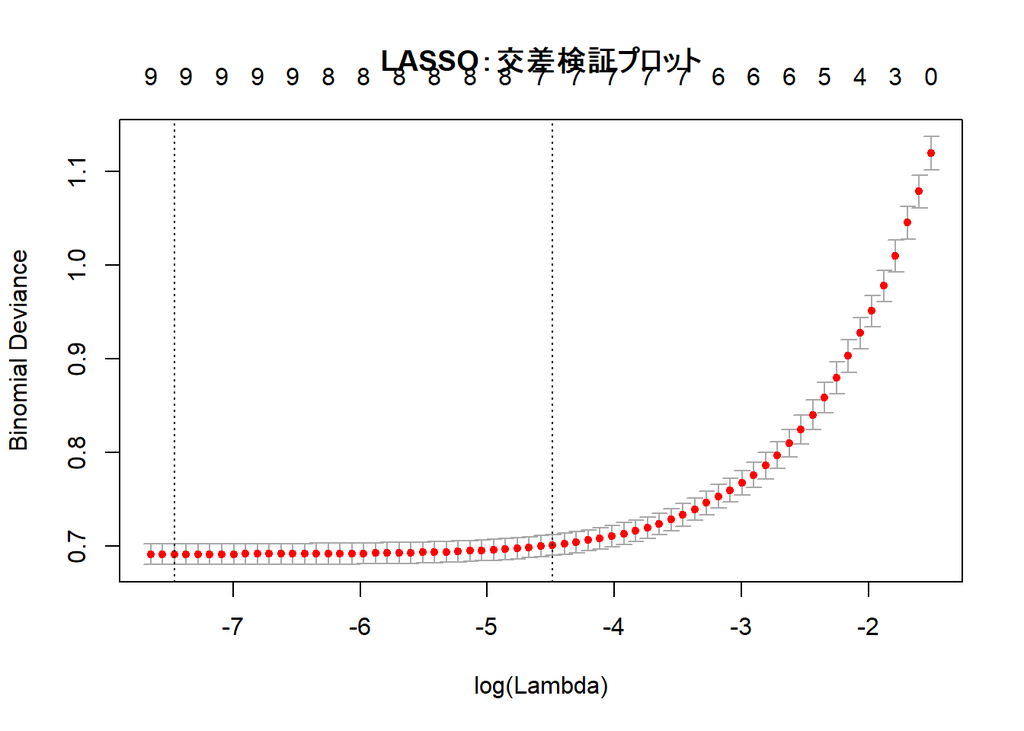

交差検証法(クロスバリデーション)により選択された正則化パラメータ(最適なλ)に対応する回帰係数(β)?  
*何かおかしい気がする。*

```r
lasso_odds <- glmnet(x_lasso, y_lasso, lambda=opt_lambda, family="binomial")$beta
exp(lasso_odds)
```

```
## 10 x 1 Matrix of class "dgeMatrix"
##                     s0
## DM          4.53108080
## Stroke     51.82670004
## MI          4.36318708
## TreatmentX  1.63529261
## sequela     1.29550085
## sex_cat     0.97533212
## age_cat0    0.02045651
## age_cat1    0.27443896
## age_cat2    1.02506961
## age_cat3    2.22866976
```

# TIP7 過学習の最小化

クロスバリデーションで最適なλを設定している。

# TIP8 アルゴリズムのパフォーマンスをMCCやPRcurveを用いて検討

ROC曲線・calibration plotを検討する。

## outcomeがどれだけ説明できているか

ROC曲線で説明度を考慮する。  
`library(pROC)`を用いて

```
##
## Call:
## roc.default(response = train$sequela, predictor = result1$fitted)
##
## Data: result1$fitted in 6894 controls (train$sequela FALSE) < 606 cases (train$sequela TRUE).
## Area under the curve: 0.577
```

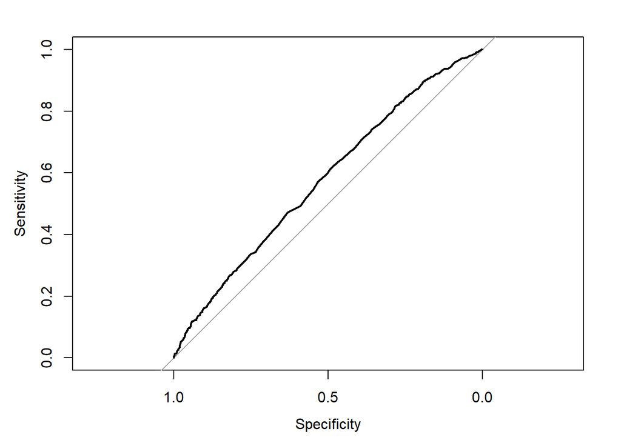

> 大して説明できてない

`library(rms)`を用いて

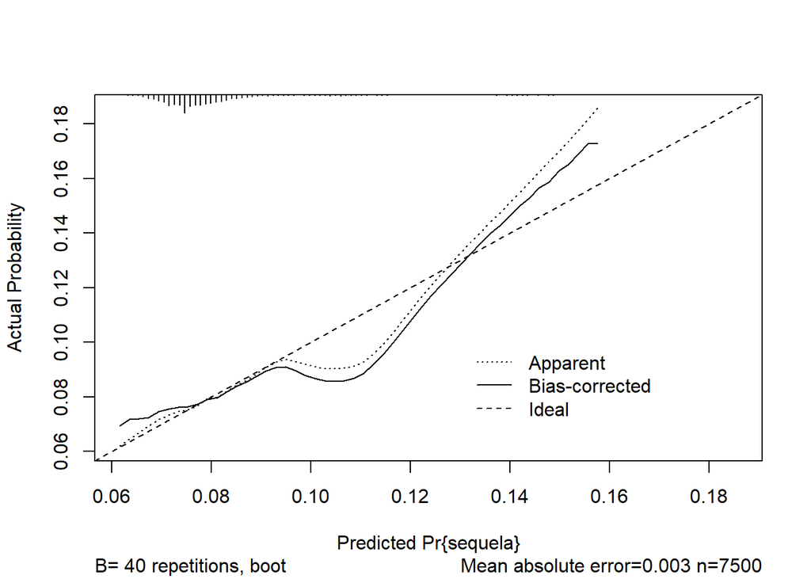

```
##
## n=7500   Mean absolute error=0.003   Mean squared error=3e-05
## 0.9 Quantile of absolute error=0.007
```

> こちらもあんまり予測できていない可能性。

# TIP9 オープンソースやplatformを用いて自分のソフトをプログラムする

今回はオープンソースの代わりに「スパース推定法による統計モデリング」を参考にした。 http://www.kyoritsu-pub.co.jp/bookdetail/9784320112575

# TIP10 専門家に質問する。

- LASSO回帰をする際に、離散変数をどのように扱ってscale()をどのように統一するべきかが解らなかった。(正規化はされているが、標準化で正規分布に近づける意味があるのか？)
- outcomeの割合が多い場合にはリスク比の予測にはポアソン回帰を使用する方が良いという報告もあった。(①実際の論文でそんな理由でポアソン回帰を施行した例を見たことほとんどないし、②ポアソン分布を二項分布から求める際にlim p -> 0の仮定をしていた気がするけれども)
- R markdownでしばしば出てくる下記の警告は放っておいて良いのかどうか(英語のQ&Aを見ていると気にしなくて良さそうなので気にしていないが) Warning message: In strsplit(code, “”, fixed = TRUE) : input string 1 is invalid in this locale
- 結局「集計の基礎」で教えて頂いた、coplotやデンドログラムや固有値などの扱い方をマスターできていない。
- glmnet()の使い方の問題かもしれないが、検証用データセットやtestデータセットでクロスバリデーションやcalibrationplotの作成ができなかった。(これは私の努力不足なので気にしないで下さい)